# Null Threshold Search for Survival Outcomes

- Show All Code
- Hide All Code
- View Source

Approximation-Driven Selection with Simulation Validation (GBSG DGM)

Author

Larry F. Leon

Published

April 14, 2026

# 1 Setup

```r
library(forestsearch)
library(weightedsurv)
library(data.table)
library(survival)
library(ggplot2)
library(patchwork)
library(gt)
library(foreach)
library(doFuture)
library(future)

# -- Safe foreach result collection -------------------------------------------
# Replaces .errorhandling = "remove" (which silently drops failures)
# with .errorhandling = "pass" + post-hoc separation of errors from results.
collect_results <- function(raw_list, label = "") {
  is_err <- vapply(raw_list, inherits, logical(1), "error")
  n_failed <- sum(is_err)
  if (n_failed > 0) {
    err_msgs <- vapply(raw_list[is_err], conditionMessage, character(1))
    warning(sprintf("%s%d of %d tasks failed.",
        if (nzchar(label)) paste0(label, ": ") else "",
        n_failed, length(raw_list)))
    message("  First errors:\n    ",
        paste(head(unique(err_msgs), 3), collapse = "\n    "))
  }
  good <- raw_list[!is_err]
  if (length(good) == 0) {
    result <- NULL
  } else if (requireNamespace("data.table", quietly = TRUE)) {
    result <- data.table::rbindlist(good, use.names = TRUE, fill = TRUE)
    result <- as.data.frame(result)
  } else {
    result <- do.call(rbind, good)
  }
  attr(result, "n_failed") <- n_failed
  attr(result, "n_total") <- length(raw_list)
  result
}


# L_eff save/load helpers
#source(here::here("../R", "leff_calibration_io.R"))
```

```r
timings <- list()
t_vignette_start <- proc.time()
```

```r
# Load L_eff calibration from C2/C3 (calibration_survival_*.qmd)
cal_survival <- tryCatch(
  load_leff_calibration("survival", output_dir = output_dir),
  error = function(e) {
    message("Calibration .rds not found: ", e$message)
    message("Using fallback values from setup chunk.")
    list(C = C_prior_fallback, alpha = alpha_prior_fallback,
         n_min = 60L, source = "fallback (hardcoded)",
         extra = list())
  }
)
```

```
#> === L_eff Calibration: survival ===
```

```
#>   C = 0.3377, alpha = -0.0618, n_min = 60
```

```
#>   DGM: GBSG survival DGM, 7 confounders (z1, z2, z3, z4, z5, size, grade3), prop_cens=0.46, p_harm=0.13
```

```
#>   Sims per N: 1000
```

```
#>   Calibrated: 2026-04-13 21:59
```

```
#>   N values: 300, 500, 700
```

```r
C_prior     <- cal_survival$C
alpha_prior <- cal_survival$alpha

# Inherit shared parameters from C2/C3's config (if available)
cfg <- cal_survival$extra
if (length(cfg) > 0) {
  cat("=== Inheriting config from survival calibration ===\n")
  if (!is.null(cfg$confounders_base)) confounders_base <- cfg$confounders_base
  if (!is.null(cfg$prop_cens))        prop_cens        <- cfg$prop_cens
  if (!is.null(cfg$p_harm))           p_harm           <- cfg$p_harm
  if (!is.null(cfg$hr_h1))            hr_h1            <- cfg$hr_h1
  if (!is.null(cfg$pcons))            pcons            <- cfg$pcons
  if (!is.null(cfg$fs_splits))        fs_splits        <- cfg$fs_splits
  if (!is.null(cfg$maxk_val))         maxk_val         <- cfg$maxk_val
  if (!is.null(cfg$n_min_val))        n_min_val        <- cfg$n_min_val
  if (!is.null(cfg$analysis_time))    analysis_time    <- cfg$analysis_time
  if (!is.null(cfg$cens_adjust))      cens_adjust      <- cfg$cens_adjust
  if (!is.null(cfg$N_cal_values))     N_cal_values     <- cfg$N_cal_values
  if (!is.null(cfg$fpr_target))       fpr_target       <- cfg$fpr_target
  cat(sprintf("  confounders: %s\n", paste(confounders_base, collapse = ", ")))
  cat(sprintf("  prop_cens=%.2f, pcons=%.2f, fs_splits=%d, maxk=%d\n",
              prop_cens, pcons, fs_splits, maxk_val))
  cat(sprintf("  fpr_target=%.2f, N_cal=%s\n",
              fpr_target, paste(N_cal_values, collapse = ", ")))

  # Grid range: clamp to C2/C3's validated range or warn
  if (!is.null(cfg$c1_range) && !is.null(cfg$c2_range)) {
    if (use_c1_grid) {
      c1_grid <- seq(cfg$c1_range[1], cfg$c1_range[2], by = grid_step)
      c2_grid <- seq(cfg$c2_range[1], cfg$c2_range[2], by = grid_step)
      cat(sprintf("  Grid clamped to calibration's validated range:\n"))
      cat(sprintf("    c1_grid = seq(%.2f, %.2f, by = %.2f) [%d values]\n",
                  min(c1_grid), max(c1_grid), grid_step, length(c1_grid)))
      cat(sprintf("    c2_grid = seq(%.2f, %.2f, by = %.2f) [%d values]\n",
                  min(c2_grid), max(c2_grid), grid_step, length(c2_grid)))
    } else {
      cat("  Grid: using user-specified values (use_c1_grid = FALSE)\n")
      if (min(c1_grid) < cfg$c1_range[1] ||
          max(c1_grid) > cfg$c1_range[2]) {
        warning(sprintf(paste0(
          "S2 c1_grid [%.2f, %.2f] extends beyond calibration's validated ",
          "range [%.2f, %.2f].\n",
          "  L_eff threshold-independence is unverified outside this range.\n",
          "  Consider expanding c1_grid in C2/C3 and re-running."),
          min(c1_grid), max(c1_grid),
          cfg$c1_range[1], cfg$c1_range[2]),
          call. = FALSE)
      }
      if (min(c2_grid) < cfg$c2_range[1] ||
          max(c2_grid) > cfg$c2_range[2]) {
        warning(sprintf(paste0(
          "S2 c2_grid [%.2f, %.2f] extends beyond calibration's validated ",
          "range [%.2f, %.2f].\n",
          "  Consider expanding c2_grid in C2/C3 and re-running."),
          min(c2_grid), max(c2_grid),
          cfg$c2_range[1], cfg$c2_range[2]),
          call. = FALSE)
      }
    }
  } else {
    cat("  Grid range: no calibration range info; using setup-chunk values.\n")
  }
} else {
  cat("=== Using fallback config from setup chunk ===\n")
  cat("(Calibration .rds not found or has no extra config)\n")
}
```

```
#> === Inheriting config from survival calibration ===
#>   confounders: z1, z2, z3, z4, z5, size, grade3
#>   prop_cens=0.46, pcons=0.90, fs_splits=400, maxk=2
#>   fpr_target=0.12, N_cal=300, 500, 700
#>   Grid clamped to calibration's validated range:
#>     c1_grid = seq(1.00, 1.50, by = 0.05) [11 values]
#>     c2_grid = seq(0.90, 1.25, by = 0.05) [8 values]
```

```r
cat(sprintf("\nL_eff prior: C = %.4f, alpha = %.4f\n",
            C_prior, alpha_prior))
```

```
#>
#> L_eff prior: C = 0.3377, alpha = -0.0618
```

```r
if (!is.null(cal_survival$dgm_description))
  cat(sprintf("Source: %s\n", cal_survival$dgm_description))
```

```
#> Source: GBSG survival DGM, 7 confounders (z1, z2, z3, z4, z5, size, grade3), prop_cens=0.46, p_harm=0.13
```

```r
if (!is.null(cal_survival$timestamp))
  cat(sprintf("Calibrated: %s\n",
              format(cal_survival$timestamp, "%Y-%m-%d %H:%M")))
```

```
#> Calibrated: 2026-04-13 21:59
```

**NoteCalibration Source**

The $L_{\text{eff}}$ prior and shared ForestSearch parameters were loaded from `_data/calibration_survival_leff.rds`, produced by `calibration_survival_fourway.qmd` (C2) or `calibration_survival_leff_grid.qmd` (C3).

- **If the `.rds` exists:** inherits `confounders_base`, `prop_cens`, `pcons`, `fs_splits`, `maxk_val`, `fpr_target`, `analysis_time`, `cens_adjust`, and `N_cal_values` from the calibration config.
- **Grid range** (`use_c1_grid = TRUE`, default): `c1_grid` and `c2_grid` are set to the calibration’s validated range at S2’s `grid_step`. Set `use_c1_grid = FALSE` to use the setup-chunk values instead (a warning is printed if they extend beyond the validated range).
- **If `.rds` not found:** uses the fallback values defined in the setup chunk.
- **To recalibrate from scratch:** set `recalibrate = TRUE`.

Note: For survival, $L_{\text{eff}} < 1$ at typical sample sizes because the events-based filters (`d0.min`, `d1.min`) aggressively prune candidates. The paper defaults (c1 = 1.25, c2 = 1.0) are already conservative for survival.

```r
plan(multisession, workers = n_workers)
cat("Using", n_workers, "parallel workers\n")
```

```
#> Using 121 parallel workers
```

```r
cat("Validation sims per config:", nsims_val, "\n")
```

```
#> Validation sims per config: 5000
```

```r
cat("FPR target:", fpr_target, "\n")
```

```
#> FPR target: 0.12
```

```r
cat("Recalibrate L_eff:", recalibrate, "\n")
```

```
#> Recalibrate L_eff: FALSE
```

# 2 Introduction

## 2.1 Strategy

Rather than sweeping a large $(c_1, c_2)$ grid by simulation (expensive), we use the **corrected approximation** to pre-screen threshold pairs and only simulate the promising candidates:

## 2.2 $L_{\text{eff}}$ Calibration Source

$$\text{FPR}_{\text{corr}}(N) = 1 - (1 - P_1)^{L_{\text{eff}}(N)},
\qquad
L_{\text{eff}}(N) = C \cdot (N / n_{\min})^\alpha$$

Prior calibration (from `calibration_survival_fourway.qmd`, GBSG survival DGM, 7 confounders): $C = 0.3376758$, $\alpha = -0.0617695$.

## Calibration Simulation Flow (from C2/C3)

**NoteHow the Calibration Simulations Work**

**C2** (`calibration_survival_fourway.qmd`) and **C3** (`calibration_survival_leff_grid.qmd`) run ForestSearch under $H_0$ to calibrate $L_{\text{eff}}$ and validate threshold-independence. S2 consumes their fitted $(C, \alpha)$ and config.

**Grid construction.** C3 defines `c1_grid` and `c2_grid` in its setup chunk. `expand.grid()` with the `c2 <= c1` filter produces the valid pairs. Each pair is crossed with `N_cal_values` (sample sizes) and `n_sims_cal` replications.

**Data generation.** `setup_gbsg_dgm(model = "null")` creates the GBSG DGM with no treatment effect. `run_simulation_analysis()` generates the data and runs ForestSearch for each replication.

**ForestSearch call.** Each task calls `forestsearch()` via `run_simulation_analysis()` with the task’s `(c1, c2)` and the shared parameters (`pcons`, `fs_splits`, `n.min`, `maxk`). Events-based filters (`d0.min`, `d1.min`) prune candidates aggressively for survival outcomes.

**Aggregation.** Results are grouped by `(n_total, c1, c2)`. The detection rate `mean(any.H)` gives the simulated FPR.

**L_eff calibration.** The per-subgroup approximation $P_1$ is computed at `n_H = n.min` using `d_eff_survival()`. The implied $L_{\text{eff}} = \log(1 - \text{FPR}_{\text{sim}}) / \log(1 - P_1)$ is computed at each `(c1, c2, N)`. Consistency across threshold pairs validates the key assumption. The power law $L_{\text{eff}}(N) = C (N/n_{\min})^\alpha$ is fitted.

**What S2 uses.** S2 loads $C$ and $\alpha$ from the calibration `.rds`. It also inherits the ForestSearch config and grid ranges. S2’s approximation grid can be denser than the calibration grid, but defaults to the validated range (see `use_c1_grid`).

# 3 Null DGM

```r
t0 <- proc.time()[3]

dgm_null <- setup_gbsg_dgm(model = "null", k_treat = 1.0,
                             verbose = TRUE)
```

```
#> === GBSG DGM Creation (Aligned) ===
```

```
#> Model type: null
```

```
#> Effect modifiers: k_treat = 1.000, k_inter = 1.000, k_z3 = 1.000
```

```
#> Sample size: 686
```

```
#> Events: 299 (43.6%)
```

```
#> Harm subgroup size: 0 (0.0%)
```

```
#> ER threshold (z1_quantile = 0.25): 8.0
```

```
#>
#> --- Original AFT Coefficients ---
```

```
#> sigma (scale): 0.7151
```

```
#> mu (intercept): 4.4590
```

```
#> gamma coefficients:
```

```
#>   treat: 0.3034
```

```
#>   z1: -0.0411
```

```
#>   z2: -0.0393
```

```
#>   z3: -0.0118
```

```
#>   z4: 0.2464
```

```
#>   z5: -0.3234
```

```
#>
#> --- Modified AFT Coefficients ---
```

```
#> gamma['treat']: 0.3034 -> 0.3034 (k_treat = 1.000)
```

```
#> gamma['z3']: -0.0118 -> -0.0118 (k_z3 = 1.000)
```

```
#>
#> --- Hazard Ratios (Stacked Potential Outcomes) ---
```

```
#> HR (overall/causal): 0.7223
```

```
#> HR (harm subgroup, H): NA
```

```
#> HR (complement, Hc): 0.7223
```

```
#>
#> --- Average Hazard Ratios (from loghr_po) ---
```

```
#> AHR (overall): 0.6543
```

```
#> AHR (harm subgroup, H): NA
```

```
#> AHR (complement, Hc): 0.6543
```

```r
cat("\nNull DGM:\n")
```

```
#>
#> Null DGM:
```

```r
cat("  HR(ITT):", round(dgm_null$hr_causal, 3), "\n")
```

```
#>   HR(ITT): 0.722
```

```r
cat("  AHR:", round(dgm_null$AHR, 3), "\n")
```

```
#>   AHR: 0.654
```

```r
timings$dgm <- proc.time()[3] - t0
```

```r
# H1 DGM: harm subgroup with HR = hr_h1 (bm1 analog = first split)
# Used only when nsims_power > 0 in the optimal pair section.
# setup_gbsg_dgm with k_treat > 1 creates heterogeneous treatment effect;
# wrap in a helper consistent with C2/C3's simulation pattern.
create_dgm_h1 <- function(hr_h1_val) {
  k_inter <- calibrate_k_inter(
    target_hr_harm = hr_h1_val,
    model = "alt", k_treat = 1.0,
    cens_type = "weibull", use_ahr = FALSE, verbose = FALSE
  )
  setup_gbsg_dgm(model = "alt", k_treat = 1.0,
                 k_inter = k_inter, verbose = FALSE)
}
```

# 4 Part I: $L_{\text{eff}}$ Calibration

## 4.1 Background

For survival, $L_{\text{eff}}$ is typically less than 1 because the events-based filters (`d0.min`, `d1.min`) prune most candidate subgroups before they reach the threshold check. This means the procedure is *more conservative* than a single per-subgroup test.

$$\text{FPR}_{\text{corr}}(N) =
1 - (1 - P_1)^{L_{\text{eff}}(N)},
\qquad
L_{\text{eff}}(N) = C \cdot (N / n_{\min})^\alpha$$

$L_{\text{eff}}$ depends on the **candidate generation process** (confounder set, GRF, LASSO, maxk, n.min, d0.min, d1.min) — not on the thresholds $(c_1, c_2)$.

## 4.2 Derived Objects

```r
# Reference subgroup at n.min
n_H_ref <- n_min_val
d_dgm <- round(d_eff_survival(n_H_ref, prop_cens))
cat(sprintf("Reference: n_H=%d (n.min), d_eff=%d events, prop_cens=%.2f\n",
            n_H_ref, d_dgm, prop_cens))
```

```
#> Reference: n_H=60 (n.min), d_eff=32 events, prop_cens=0.46
```

```r
# Convenience wrapper
p_detect_glm <- function(theta, d_eff, c1, c2) {
  compute_detection_probability_glm(
    theta = theta, d_eff = d_eff, c1 = c1, c2 = c2,
    effect_scale = "ratio", method = "monte_carlo"
  )
}

# Compound parameter objects from setup-chunk scalars
fs_params_base <- list(
  hr.threshold = 1.25,
  hr.consistency = 1.0,
  pconsistency.threshold = pcons,
  fs.splits = fs_splits,
  n.min = n_min_val,
  d0.min = 12, d1.min = 12,
  maxk = maxk_val, by.risk = 12,
  vi.grf.min = -0.2,
  use_lasso = TRUE, use_grf = TRUE,
  use_twostage = TRUE, twostage_args = list(),
  parallel_args = list(plan="sequential", workers = 1, show_message = FALSE)
)

fs_params_cox <- modifyList(fs_params_base, list(
  outcome.name = "y_sim", event.name = "event_sim",
  treat.name = "treat_sim", id.name = "id"
))

sim_config <- list(
  n_sample = n_sample,
  analysis_time = analysis_time,
  cens_adjust = cens_adjust
)

cat(sprintf("n.min=%d, pcons=%.2f, maxk=%d\n",
            n_min_val, pcons, maxk_val))
```

```
#> n.min=60, pcons=0.90, maxk=2
```

## 4.3 Calibration Simulation

Set `recalibrate = TRUE` in the setup chunk to execute. When `FALSE`, the prior values ($C = 0.3376758$, $\alpha = -0.0617695$) are used.

**To adapt for a new scenario**: modify `setup_gbsg_dgm()`, the `confounders_base` list, and `fs_params_cox` for your DGM. Then set `recalibrate = TRUE`.

```r
if (recalibrate) {
  c1_cal <- 1.25
  c2_cal <- 1.0

  cat(sprintf("=== L_eff Calibration ===\n"))
  cat(sprintf("Reference thresholds: c1=%.2f, c2=%.2f\n",
              c1_cal, c2_cal))
  cat(sprintf("N values: %s\n", paste(N_cal_values, collapse=", ")))
  cat(sprintf("Sims per N: %d\n\n", n_sims_recal))

  t0 <- proc.time()[3]

  cal_results <- list()
  for (N_val in N_cal_values) {
    t_N <- proc.time()[3]

    res_N_raw <- foreach(
      sim = seq_len(n_sims_recal),
      .errorhandling = "pass",
      .options.future = list(
        packages = c("forestsearch", "survival", "data.table", "future"),
        seed = TRUE)
    ) %dofuture% {
      future::plan("sequential")
      fs_params_cal <- modifyList(fs_params_cox, list(
        hr.threshold = c1_cal,
        hr.consistency = c2_cal
      ))
      run_simulation_analysis(
        sim_id = sim, dgm = dgm_null,
        n_sample = N_val,
        analysis_time = sim_config$analysis_time,
        cens_adjust = sim_config$cens_adjust,
        confounders_base = confounders_base,
        cox_formula_adj = survival::Surv(y_sim, event_sim) ~
          treat_sim + z1 + z2 + z3,
        n_add_noise = 0L,
        run_fs = TRUE, run_fs_grf = FALSE, run_grf = FALSE,
        fs_params = fs_params_cal, verbose = FALSE
      )
    }

    res_N <- collect_results(res_N_raw, sprintf("N=%d", N_val))
    fs_rows <- res_N[res_N$analysis == "FS", ]
    if (nrow(fs_rows) < n_sims_recal) {
      warning(sprintf(
        "Calibration N=%d: %d of %d tasks silently failed.",
        N_val, n_sims_recal - nrow(fs_rows), n_sims_recal
      ))
    }
    fpr_N <- mean(fs_rows$any.H, na.rm = TRUE)
    cal_results[[as.character(N_val)]] <- data.frame(
      N = N_val, sim_fpr = fpr_N, n_sims = nrow(fs_rows)
    )
    cat(sprintf("  N = %4d: FPR = %.3f (%d sims) | %.1f sec\n",
        N_val, fpr_N, nrow(fs_rows), proc.time()[3] - t_N))
  }

  timings$leff_cal <- proc.time()[3] - t0
  cat(sprintf("\nCalibration: %.1f min\n", timings$leff_cal / 60))

} else {
  timings$leff_cal <- 0
  cat("Calibration skipped (recalibrate = FALSE).\n")
  cat("Using prior values from calibration_survival_*.qmd.\n")
}
```

```
#> Calibration skipped (recalibrate = FALSE).
#> Using prior values from calibration_survival_*.qmd.
```

## 4.4 Fit $L_{\text{eff}}$ Power Law

```r
if (recalibrate) {
  cal_df <- do.call(rbind, cal_results)
  cal_df$n_H <- n_min_val
  cal_df$d_eff <- round(d_eff_survival(cal_df$n_H, prop_cens))
  cal_df$P1 <- sapply(cal_df$d_eff, function(d)
    p_detect_glm(1.0, d, 1.25, 1.0))

  cal_df$sim_fpr <- pmax(cal_df$sim_fpr, 0.5 / n_sims_recal)
  cal_df$sim_fpr <- pmin(cal_df$sim_fpr, 1 - 0.5 / n_sims_recal)
  cal_df$L_eff <- log(1 - cal_df$sim_fpr) / log(1 - cal_df$P1)

  cat("=== Implied L_eff ===\n")
  print(cal_df[, c("N", "n_H", "d_eff", "P1", "sim_fpr", "L_eff")])

  cal_valid <- cal_df[is.finite(cal_df$L_eff) &
                       cal_df$L_eff > 0, ]

  if (nrow(cal_valid) >= 2) {
    leff_cal <- calibrate_L_eff(
      N = cal_valid$N, P1 = cal_valid$P1,
      sim_fpr = cal_valid$sim_fpr, n_min = n_min_val
    )
    C_fit <- leff_cal$C
    alpha_fit <- leff_cal$alpha
    print(leff_cal)

    N_pred <- seq(200, 1200, by = 5)
    pred_curve <- data.frame(
      N = N_pred,
      L_eff = C_fit * (N_pred / n_min_val)^alpha_fit
    )

    print(
      ggplot() +
        geom_point(data = cal_valid, aes(x = N, y = L_eff),
                   size = 4, colour = "firebrick") +
        geom_line(data = pred_curve, aes(x = N, y = L_eff),
                  colour = "steelblue", linewidth = 1) +
        labs(x = "Total Sample Size N",
             y = expression(L[eff]),
             title = expression(
               L[eff] * " Calibration: GBSG Survival DGM"),
             subtitle = sprintf(
               "L_eff = %.3f * (N/%d)^%.3f  (R-sq = %.3f)",
               C_fit, n_min_val, alpha_fit,
               leff_cal$r_squared)) +
        theme_minimal(base_size = 12) +
        theme(plot.title = element_text(face = "bold"))
    )
  } else {
    cat("Insufficient calibration points; using prior.\n")
    C_fit <- C_prior; alpha_fit <- alpha_prior
  }

  # Save updated calibration
  save_leff_calibration(
    C = C_fit, alpha = alpha_fit, n_min = n_min_val,
    outcome_type = "survival",
    cal_data = cal_df,
    dgm_description = paste(
      "GBSG survival DGM,", length(confounders_base), "confounders",
      sprintf("prop_cens=%.2f, p_harm=%.2f", prop_cens, p_harm)),
    n_sims_per_N = n_sims_recal,
    output_dir = output_dir
  )

} else {
  C_fit <- C_prior
  alpha_fit <- alpha_prior
  cat(sprintf("Using prior: C = %.3f, alpha = %.3f\n",
              C_fit, alpha_fit))
}
```

```
#> Using prior: C = 0.338, alpha = -0.062
```

## 4.5 $L_{\text{eff}}$ Summary

```r
cat("=== L_eff Model ===\n")
```

```
#> === L_eff Model ===
```

```r
cat(sprintf("  L_eff(N) = %.3f * (N/%d)^%.3f\n\n",
            C_fit, n_min_val, alpha_fit))
```

```
#>   L_eff(N) = 0.338 * (N/60)^-0.062
```

```r
cat("=== L_eff at Target Sample Sizes ===\n")
```

```
#> === L_eff at Target Sample Sizes ===
```

```r
for (N_val in N_target) {
  L <- C_fit * (N_val / n_min_val)^alpha_fit
  cat(sprintf("  N = %4d: L_eff = %.2f%s\n", N_val, L,
              if (L < 1) " (< 1: procedure more conservative than per-subgroup)"
              else ""))
}
```

```
#>   N =  300: L_eff = 0.31 (< 1: procedure more conservative than per-subgroup)
#>   N =  500: L_eff = 0.30 (< 1: procedure more conservative than per-subgroup)
#>   N =  700: L_eff = 0.29 (< 1: procedure more conservative than per-subgroup)
```

```r
cat(sprintf("\n=== Source: %s ===\n",
  if (recalibrate) "calibrated in this run" else "prior"))
```

```
#>
#> === Source: prior ===
```

```r
cat("\nNote: L_eff < 1 means the procedure is MORE conservative\n")
```

```
#>
#> Note: L_eff < 1 means the procedure is MORE conservative
```

```r
cat("than a single per-subgroup test (events filters prune candidates).\n")
```

```
#> than a single per-subgroup test (events filters prune candidates).
```

## Adapting for Other Scenarios

**TipBlueprint: How to Calibrate for a New Survival DGM**

**Step 1.** Replace `setup_gbsg_dgm()` with your H0 data generator.

**Step 2.** Update `confounders_base` and `fs_params_cox` in the `leff-params` chunk to match your analysis configuration.

**Step 3.** Update `prop_cens` (for `d_eff_survival()`) and `p_harm` in the setup chunk.

**Step 4.** Set `recalibrate = TRUE` and `n_sims_recal` to at least 200.

**Step 5.** After the calibration run, record the fitted $C$ and $\alpha$ as your new `C_prior` / `alpha_prior` in the setup chunk for future runs with `recalibrate = FALSE`.

# 5 Part II: Approximation-Driven Selection

## 5.1 Dense Approximation Grid

```r
# Grid defined in setup: c1_grid, c2_grid, N_target
full_grid <- expand.grid(c1 = c1_grid, c2 = c2_grid,
                          N = N_target,
                          stringsAsFactors = FALSE)
full_grid <- full_grid[full_grid$c2 <= full_grid$c1, ]

# Compute corrected FPR for every (c1, c2, N)
full_grid$n_H <- n_min_val
full_grid$d_eff <- round(d_eff_survival(full_grid$n_H, prop_cens))
full_grid$L_eff <- C_fit * (full_grid$N / n_min_val)^alpha_fit

full_grid$P1 <- mapply(function(d, c1v, c2v) {
  p_detect_glm(1.0, d, c1v, c2v)
}, full_grid$d_eff, full_grid$c1, full_grid$c2)

full_grid$FPR_corr <- 1 - (1 - full_grid$P1)^full_grid$L_eff

full_dt <- data.table(full_grid)

cat(sprintf("Dense grid: %d c1 x %d c2 x %d N = %d configs\n",
    length(c1_grid), length(c2_grid), length(N_target),
    nrow(full_dt)))
```

```
#> Dense grid: 11 c1 x 8 c2 x 3 N = 216 configs
```

```r
cat(sprintf("(c1 range: %.2f--%.2f, c2 range: %.2f--%.2f)\n",
    min(c1_grid), max(c1_grid), min(c2_grid), max(c2_grid)))
```

```
#> (c1 range: 1.00--1.50, c2 range: 0.90--1.25)
```

## 5.2 Corrected FPR Heatmaps

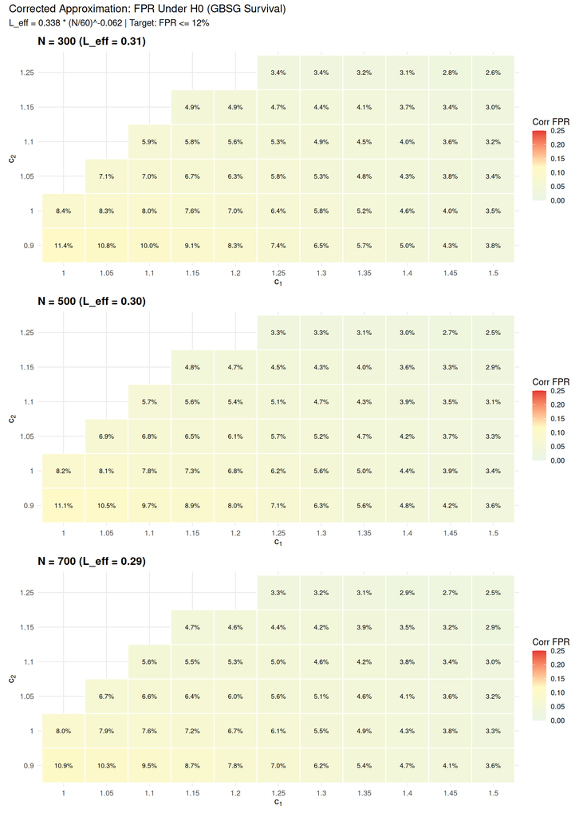

Corrected approximation FPR. For survival with L_eff < 1, the corrected FPR is LOWER than P1.

```r
heat_sub <- full_dt[c1 %in% c1_heat & c2 %in% c2_heat]

heatmap_list <- lapply(N_target, function(N_val) {
  sub <- heat_sub[N == N_val]
  ggplot(sub, aes(x = factor(c1), y = factor(c2),
                  fill = FPR_corr)) +
    geom_tile(colour = "white", linewidth = 0.5) +
    geom_text(aes(label = sprintf("%.1f%%", 100 * FPR_corr)),
              size = 2.8, colour = "black") +
    scale_fill_gradient2(
      low = "#E8F5E9", mid = "#FFF9C4", high = "#E53935",
      midpoint = fpr_target,
      limits = c(0, max(heat_sub$FPR_corr, 0.25)),
      name = "Corr FPR"
    ) +
    labs(x = expression(c[1]), y = expression(c[2]),
         title = sprintf("N = %d (L_eff = %.2f)", N_val,
           C_fit * (N_val / n_min_val)^alpha_fit)) +
    theme_minimal(base_size = 11) +
    theme(plot.title = element_text(face = "bold"),
          axis.text = element_text(size = 9))
})

wrap_plots(heatmap_list, ncol = 1) +
  plot_annotation(
    title = "Corrected Approximation: FPR Under H0 (GBSG Survival)",
    subtitle = sprintf(
      "L_eff = %.3f * (N/%d)^%.3f | Target: FPR <= %.0f%%",
      C_fit, n_min_val, alpha_fit, 100 * fpr_target))
```

## 5.3 Pre-Select: Smallest $(c_1, c_2)$ Meeting the Target

```r
N_max <- max(N_target)
fpr_wide <- full_dt[, .(
  FPR_corr_worst = FPR_corr[N == N_max]
), by = .(c1, c2)]

for (N_val in N_target) {
  col_name <- sprintf("FPR_N%d", N_val)
  fpr_wide[[col_name]] <- full_dt[N == N_val,
    FPR_corr[match(paste(fpr_wide$c1, fpr_wide$c2),
                   paste(c1, c2))]]
}

selected <- fpr_wide[FPR_corr_worst <= fpr_target]
setorder(selected, c1, c2)

cat(sprintf(
  "Pairs with corrected FPR <= %.0f%% at N=%d: %d of %d\n",
  100 * fpr_target, N_max, nrow(selected), nrow(fpr_wide)))
```

```
#> Pairs with corrected FPR <= 12% at N=700: 72 of 72
```

```r
# Frontier: minimum c2 for each c1
frontier <- selected[, .(
  min_c2 = min(c2),
  FPR_at_min_c2 = FPR_corr_worst[which.min(c2)]
), by = c1]
setorder(frontier, c1)

if (nrow(frontier) > 0) {
  cat(sprintf("\nSmallest c1 achieving target: %.2f (with c2=%.2f)\n",
      frontier$c1[1], frontier$min_c2[1]))

  gt(frontier[, .(
    c1,
    `Min c2` = min_c2,
    `Corr FPR (worst N)` = sprintf("%.1f%%", 100 * FPR_at_min_c2)
  )]) |>
    tab_header(
      title = md(sprintf(
        "**Frontier: Minimum c2 for Each c1 (FPR <= %.0f%%)**",
        100 * fpr_target)),
      subtitle = sprintf(
        "Binding at N=%d (L_eff=%.2f) | Paper defaults: c1=1.25, c2=1.0",
        N_max, C_fit * (N_max / n_min_val)^alpha_fit)
    ) |>
    tab_style(style = cell_fill(color = "#E8F5E9"),
      locations = cells_body(rows = c1 == 1.25))
} else {
  cat("No c1 values achieved the target.\n")
}
```

```
#>
#> Smallest c1 achieving target: 1.00 (with c2=0.90)
```

Frontier: minimum c2 for each c1 to achieve corrected FPR <= target at all N

**Frontier: Minimum c2 for Each c1 (FPR <= 12%)**

Binding at N=700 (L_eff=0.29) | Paper defaults: c1=1.25, c2=1.0

| c1 | Min c2 | Corr FPR (worst N) |
| --- | --- | --- |
| 1.00 | 0.9 | 10.9% |
| 1.05 | 0.9 | 10.3% |
| 1.10 | 0.9 | 9.5% |
| 1.15 | 0.9 | 8.7% |
| 1.20 | 0.9 | 7.8% |
| 1.25 | 0.9 | 7.0% |
| 1.30 | 0.9 | 6.2% |
| 1.35 | 0.9 | 5.4% |
| 1.40 | 0.9 | 4.7% |
| 1.45 | 0.9 | 4.1% |
| 1.50 | 0.9 | 3.6% |

## 5.4 Optimal Pair: Power Curve

The frontier identifies the **least restrictive** thresholds that still control FPR. We extract $(c_{1,\min}, c_{2,\min})$ — the smallest $c_1$ achieving the target, paired with its minimum $c_2$ — and plot the power curve.

**ImportantWhy the $L_{\text{eff}}$ Correction Is Asymmetric**

**Under $H_0$ (FPR):** the procedure evaluates $\sim L_{\text{eff}}$ approximately independent candidates, so:

$$\text{FPR}_{\text{corr}} = 1 - (1 - P_1)^{L_{\text{eff}}}$$

For survival with $L_{\text{eff}} < 1$, the corrected FPR is *lower* than $P_1$, confirming the paper defaults are conservative.

**Under $H_1$ (power):** there is one true harm subgroup with effect $\theta^\dagger(H)$. Its detection probability is $P_1(\theta^\dagger)$. The uncorrected $P_1$ is the primary power measure (probability of detecting the correct subgroup). The corrected $1 - (1-P_1)^{L_{\text{eff}}}$ slightly adjusts for multi-candidate evaluation.

When `nsims_power > 0`, a targeted $H_1$ simulation is run at $\text{HR} = 2$ for the optimal pair to spot-check $P_1$ accuracy at the effect size of interest.

```
#> === Optimal Pair: c1 = 1.00, c2 = 0.90 ===
#> Corrected FPR at this pair: 10.9% (target: 12%)
#>
#> --- Running 500 H1 sims at HR = 2.0 ---
```

```
#>   N =  300: Sim power = 38.0% (190/500) | L_eff = 0.31
#>   N =  500: Sim power = 75.0% (375/500) | L_eff = 0.30
#>   N =  700: Sim power = 88.2% (441/500) | L_eff = 0.29
#> Power simulation: 2.5 min
```

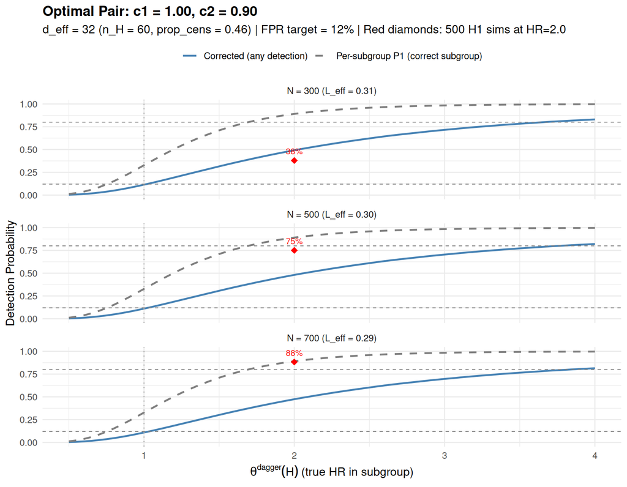

Power curve for optimal pair (c1=1.00, c2=0.90). Solid blue = corrected, dashed grey = per-subgroup P1, red diamonds = simulation (if run).

```
#>
#> === Power at Key Effect Sizes ===
#> HR=1.00 : N=300 P1=32.8% Corr=11.4%  N=500 P1=32.8% Corr=11.1%  N=700 P1=32.8% Corr=10.9%
#> HR=1.25 : N=300 P1=54.4% Corr=21.4%  N=500 P1=54.4% Corr=20.8%  N=700 P1=54.4% Corr=20.4%
#> HR=1.50 : N=300 P1=71.0% Corr=31.5%  N=500 P1=71.0% Corr=30.7%  N=700 P1=71.0% Corr=30.2%
#> HR=2.00 : N=300 P1=89.1% Corr=49.2%  N=500 P1=89.1% Corr=48.1%  N=700 P1=89.1% Corr=47.4%
#> HR=2.50 : N=300 P1=95.9% Corr=62.2%  N=500 P1=95.9% Corr=61.1%  N=700 P1=95.9% Corr=60.3%
#> HR=3.00 : N=300 P1=98.4% Corr=71.6%  N=500 P1=98.4% Corr=70.5%  N=700 P1=98.4% Corr=69.7%
```

```r
if (exists("frontier") && nrow(frontier) > 0) {

  c1_opt <- frontier$c1[1]
  c2_opt <- frontier$min_c2[1]

  cat(sprintf("=== Optimal Pair: c1 = %.2f, c2 = %.2f ===\n",
              c1_opt, c2_opt))
  cat(sprintf("Corrected FPR at this pair: %.1f%% (target: %.0f%%)\n",
              100 * frontier$FPR_at_min_c2[1], 100 * fpr_target))

  # ── Approximation power curve ──────────────────────────────
  d_ref <- d_dgm  # d_eff at n.min
  hr_seq <- seq(0.5, 4.0, by = 0.05)

  power_curves <- do.call(rbind, lapply(N_target, function(N_val) {
    L_eff <- C_fit * (N_val / n_min_val)^alpha_fit
    data.frame(
      HR = rep(hr_seq, 2),
      Power = c(
        sapply(hr_seq, function(hr) {
          P1 <- p_detect_glm(hr, d_ref, c1_opt, c2_opt)
          1 - (1 - P1)^L_eff
        }),
        sapply(hr_seq, function(hr) {
          p_detect_glm(hr, d_ref, c1_opt, c2_opt)
        })
      ),
      Type = rep(c("Corrected (any detection)",
                   "Per-subgroup P1 (correct subgroup)"),
                 each = length(hr_seq)),
      N = sprintf("N = %d (L_eff = %.2f)", N_val, L_eff)
    )
  }))

  # ── Targeted H1 simulation at hr_h1 ────────────────────────
  sim_power_points <- NULL
  if (nsims_power > 0) {
    cat(sprintf("\n--- Running %d H1 sims at HR = %.1f ---\n",
                nsims_power, hr_h1))
    t0_power <- proc.time()[3]

    dgm_h1 <- create_dgm_h1(hr_h1)

    # Reset workers before power simulation phase
    future::plan("sequential")
    future::plan("multisession", workers = n_workers)

    sim_power_results <- do.call(rbind, lapply(N_target, function(N_val) {
      found <- foreach(
        s = seq_len(nsims_power),
        .combine = c, .errorhandling = "pass",
        .options.future = list(
          packages = c("forestsearch", "survival", "data.table", "future"),
          seed = TRUE)
      ) %dofuture% {
        future::plan("sequential")
        fs_params_opt <- modifyList(fs_params_cox, list(
          hr.threshold = c1_opt,
          hr.consistency = c2_opt
        ))
        res <- run_simulation_analysis(
          sim_id = s, dgm = dgm_h1,
          n_sample = N_val,
          analysis_time = sim_config$analysis_time,
          cens_adjust = sim_config$cens_adjust,
          confounders_base = confounders_base,
          cox_formula_adj = survival::Surv(y_sim, event_sim) ~
            treat_sim + z1 + z2 + z3,
          n_add_noise = 0L,
          run_fs = TRUE, run_fs_grf = FALSE, run_grf = FALSE,
          fs_params = fs_params_opt, verbose = FALSE
        )
        fs_row <- res[res$analysis == "FS", ]
        if (nrow(fs_row) > 0) fs_row$any.H[1] else 0L
      }
      res_clean <- unlist(found[sapply(found, is.numeric)])
      if (length(res_clean) < nsims_power) {
        warning(sprintf(
          "H1 N=%d: %d of %d tasks silently failed.",
          N_val, nsims_power - length(res_clean), nsims_power
        ))
      }
      sim_pwr <- mean(res_clean, na.rm = TRUE)
      L_eff <- C_fit * (N_val / n_min_val)^alpha_fit
      cat(sprintf("  N = %4d: Sim power = %.1f%% (%d/%d) | L_eff = %.2f\n",
                  N_val, 100 * sim_pwr, sum(res_clean),
                  length(res_clean), L_eff))
      data.frame(
        HR = hr_h1, Power = sim_pwr,
        Type = "Simulation",
        N = sprintf("N = %d (L_eff = %.2f)", N_val, L_eff))
    }))

    sim_power_points <- sim_power_results
    timings$power <- proc.time()[3] - t0_power
    cat(sprintf("Power simulation: %.1f min\n",
                timings$power / 60))
  } else {
    timings$power <- 0
  }

  # ── Plot ────────────────────────────────────────────────────
  p <- ggplot(power_curves, aes(x = HR, y = Power,
                                 linetype = Type, colour = Type)) +
    geom_line(linewidth = 0.9) +
    geom_hline(yintercept = c(fpr_target, 0.80),
               linetype = "dashed", colour = "grey50", linewidth = 0.4) +
    geom_vline(xintercept = 1.0, linetype = "dotted", colour = "grey70")

  if (!is.null(sim_power_points)) {
    p <- p +
      geom_point(data = sim_power_points,
                 aes(x = HR, y = Power),
                 colour = "red", size = 3, shape = 18,
                 inherit.aes = FALSE) +
      geom_text(data = sim_power_points,
                aes(x = HR, y = Power,
                    label = sprintf("%.0f%%", 100 * Power)),
                colour = "red", vjust = -1, size = 3,
                inherit.aes = FALSE)
  }

  p <- p +
    facet_wrap(~ N, ncol = 1) +
    scale_linetype_manual(values = c(
      "Corrected (any detection)" = "solid",
      "Per-subgroup P1 (correct subgroup)" = "dashed")) +
    scale_colour_manual(values = c(
      "Corrected (any detection)" = "steelblue",
      "Per-subgroup P1 (correct subgroup)" = "grey50")) +
    labs(x = expression(theta^dagger*(H) ~ "(true HR in subgroup)"),
         y = "Detection Probability",
         title = sprintf("Optimal Pair: c1 = %.2f, c2 = %.2f",
                          c1_opt, c2_opt),
         subtitle = sprintf(
           "d_eff = %d (n_H = %d, prop_cens = %.2f) | FPR target = %.0f%%%s",
           d_ref, n_min_val, prop_cens, 100 * fpr_target,
           if (nsims_power > 0)
             sprintf(" | Red diamonds: %d H1 sims at HR=%.1f",
                     nsims_power, hr_h1) else ""),
         linetype = NULL, colour = NULL) +
    theme_minimal(base_size = 12) +
    theme(legend.position = "top",
          plot.title = element_text(face = "bold"))
  print(p)

  # ── Power summary table ────────────────────────────────────
  cat("\n=== Power at Key Effect Sizes ===\n")
  for (hr_val in c(1.0, 1.25, 1.50, hr_h1, 2.5, 3.0)) {
    cat(sprintf("HR=%-5.2f: ", hr_val))
    for (N_val in N_target) {
      L_eff <- C_fit * (N_val / n_min_val)^alpha_fit
      P1 <- p_detect_glm(hr_val, d_ref, c1_opt, c2_opt)
      P_corr <- 1 - (1 - P1)^L_eff
      cat(sprintf("N=%d P1=%.1f%% Corr=%.1f%%  ",
                  N_val, 100 * P1, 100 * P_corr))
    }
    cat("\n")
  }

} else {
  cat("No frontier found. Cannot compute optimal pair power curve.\n")
  cat("Consider expanding c1_grid/c2_grid or relaxing fpr_target.\n")
}
```

```r
if (exists("c1_opt")) {

  hr_vals <- unique(sort(c(1.0, 1.25, 1.50, hr_h1, 2.5, 3.0)))

  power_tbl <- do.call(rbind, lapply(hr_vals, function(hr_val) {
    row <- data.frame(HR = hr_val, stringsAsFactors = FALSE)
    for (N_val in N_target) {
      L_eff <- C_fit * (N_val / n_min_val)^alpha_fit
      P1 <- p_detect_glm(hr_val, d_ref, c1_opt, c2_opt)
      P_corr <- 1 - (1 - P1)^L_eff
      row[[sprintf("P1_N%d", N_val)]]   <- P1
      row[[sprintf("Corr_N%d", N_val)]] <- P_corr

      if (!is.null(sim_power_points) && abs(hr_val - hr_h1) < 0.01) {
        sp <- sim_power_points[
          sim_power_points$N == sprintf("N = %d (L_eff = %.2f)",
                                         N_val, L_eff), ]
        row[[sprintf("Sim_N%d", N_val)]] <- if (nrow(sp) > 0)
          sp$Power[1] else NA_real_
      } else {
        row[[sprintf("Sim_N%d", N_val)]] <- NA_real_
      }
    }
    row
  }))

  tbl <- gt(power_tbl) |>
    fmt_percent(columns = -HR, decimals = 1) |>
    sub_missing(missing_text = "\u2014") |>
    fmt_number(columns = HR, decimals = 2)

  for (N_val in N_target) {
    tbl <- tbl |>
      tab_spanner(
        label = sprintf("N = %d", N_val),
        columns = starts_with(c(sprintf("P1_N%d", N_val),
                                sprintf("Corr_N%d", N_val),
                                sprintf("Sim_N%d", N_val)))
      ) |>
      cols_label(
        !!sprintf("P1_N%d", N_val)   := "P1",
        !!sprintf("Corr_N%d", N_val) := "Corrected",
        !!sprintf("Sim_N%d", N_val)  := "Simulation"
      )
  }

  if (is.null(sim_power_points)) {
    sim_cols <- sprintf("Sim_N%d", N_target)
    tbl <- tbl |> cols_hide(columns = any_of(sim_cols))
  }

  tbl |>
    tab_header(
      title = sprintf("Power: Optimal Pair (c1 = %.2f, c2 = %.2f)",
                      c1_opt, c2_opt),
      subtitle = sprintf(
        "d_eff = %d (n_H = %d, prop_cens = %.2f) | P1 = correct subgroup%s",
        d_ref, n_min_val, prop_cens,
        if (!is.null(sim_power_points))
          sprintf(" | Sim: %d sims at HR = %.1f", nsims_power, hr_h1)
        else "")
    ) |>
    tab_style(
      style = cell_fill(color = "#E8F5E9"),
      locations = cells_body(
        columns = starts_with("P1_"),
        rows = HR == hr_h1)
    ) |>
    tab_style(
      style = cell_text(weight = "bold"),
      locations = cells_body(rows = HR == hr_h1)
    ) |>
    tab_source_note(sprintf(
      "P1 = per-subgroup detection (primary power measure) | Corrected = 1-(1-P1)^L_eff | HR = %.1f row highlighted",
      hr_h1))
}
```

Power at optimal pair (c1 = 1.00, c2 = 0.90) by sample size and effect size

Power: Optimal Pair (c1 = 1.00, c2 = 0.90)

d_eff = 32 (n_H = 60, prop_cens = 0.46) | P1 = correct subgroup | Sim: 500 sims at HR = 2.0

| HR | N = 300 P1 | N = 300 Corrected | N = 300 Simulation | N = 500 P1 | N = 500 Corrected | N = 500 Simulation | N = 700 P1 | N = 700 Corrected | N = 700 Simulation |
| --- | --- | --- | --- | --- | --- | --- | --- | --- | --- |
| 1.00 | 32.8% | 11.4% | — | 32.8% | 11.1% | — | 32.8% | 10.9% | — |
| 1.25 | 54.4% | 21.4% | — | 54.4% | 20.8% | — | 54.4% | 20.4% | — |
| 1.50 | 71.0% | 31.5% | — | 71.0% | 30.7% | — | 71.0% | 30.2% | — |
| 2.00 | 89.1% | 49.2% | 38.0% | 89.1% | 48.1% | 75.0% | 89.1% | 47.4% | 88.2% |
| 2.50 | 95.9% | 62.2% | — | 95.9% | 61.1% | — | 95.9% | 60.3% | — |
| 3.00 | 98.4% | 71.6% | — | 98.4% | 70.5% | — | 98.4% | 69.7% | — |

P1 = per-subgroup detection (primary power measure) | Corrected = 1-(1-P1)^L_eff | HR = 2.0 row highlighted

## 5.5 Full Selected Pairs Table

```r
if (nrow(selected) > 0) {
  display_cols <- c("c1", "c2", "FPR_corr_worst")
  for (N_val in N_target) {
    display_cols <- c(display_cols, sprintf("FPR_N%d", N_val))
  }

  display_dt <- selected[, ..display_cols]
  names(display_dt)[3] <- "Worst Case"
  for (N_val in N_target) {
    old_name <- sprintf("FPR_N%d", N_val)
    new_name <- sprintf("N=%d", N_val)
    names(display_dt)[names(display_dt) == old_name] <- new_name
  }

  for (col in names(display_dt)[3:ncol(display_dt)]) {
    display_dt[[col]] <- sprintf("%.1f%%", 100 * display_dt[[col]])
  }

  gt(display_dt) |>
    tab_header(
      title = md(sprintf(
        "**All Pairs with Corrected FPR <= %.0f%%**",
        100 * fpr_target)),
      subtitle = "Sorted by c1 (ascending), then c2 (ascending)"
    ) |>
    tab_spanner(
      label = "Corrected FPR by N",
      columns = 4:ncol(display_dt)
    ) |>
    tab_source_note(
      "Worst Case = max corrected FPR across N values"
    )
} else {
  cat("No pairs met the target.\n")
}
```

All pairs meeting the corrected FPR target, sorted by c1 then c2

**All Pairs with Corrected FPR <= 12%**

Sorted by c1 (ascending), then c2 (ascending)

| c1 | c2 | Worst Case | Corrected FPR by N N=300 | Corrected FPR by N N=500 | Corrected FPR by N N=700 |
| --- | --- | --- | --- | --- | --- |
| 1.00 | 0.90 | 10.9% | 11.4% | 11.1% | 10.9% |
| 1.00 | 0.95 | 9.5% | 10.0% | 9.7% | 9.5% |
| 1.00 | 1.00 | 8.0% | 8.4% | 8.2% | 8.0% |
| 1.05 | 0.90 | 10.3% | 10.8% | 10.5% | 10.3% |
| 1.05 | 0.95 | 9.1% | 9.6% | 9.3% | 9.1% |
| 1.05 | 1.00 | 7.9% | 8.3% | 8.1% | 7.9% |
| 1.05 | 1.05 | 6.7% | 7.1% | 6.9% | 6.7% |
| 1.10 | 0.90 | 9.5% | 10.0% | 9.7% | 9.5% |
| 1.10 | 0.95 | 8.6% | 9.1% | 8.8% | 8.6% |
| 1.10 | 1.00 | 7.6% | 8.0% | 7.8% | 7.6% |
| 1.10 | 1.05 | 6.6% | 7.0% | 6.8% | 6.6% |
| 1.10 | 1.10 | 5.6% | 5.9% | 5.7% | 5.6% |
| 1.15 | 0.90 | 8.7% | 9.1% | 8.9% | 8.7% |
| 1.15 | 0.95 | 8.0% | 8.4% | 8.1% | 8.0% |
| 1.15 | 1.00 | 7.2% | 7.6% | 7.3% | 7.2% |
| 1.15 | 1.05 | 6.4% | 6.7% | 6.5% | 6.4% |
| 1.15 | 1.10 | 5.5% | 5.8% | 5.6% | 5.5% |
| 1.15 | 1.15 | 4.7% | 4.9% | 4.8% | 4.7% |
| 1.20 | 0.90 | 7.8% | 8.3% | 8.0% | 7.8% |
| 1.20 | 0.95 | 7.3% | 7.7% | 7.4% | 7.3% |
| 1.20 | 1.00 | 6.7% | 7.0% | 6.8% | 6.7% |
| 1.20 | 1.05 | 6.0% | 6.3% | 6.1% | 6.0% |
| 1.20 | 1.10 | 5.3% | 5.6% | 5.4% | 5.3% |
| 1.20 | 1.15 | 4.6% | 4.9% | 4.7% | 4.6% |
| 1.25 | 0.90 | 7.0% | 7.4% | 7.1% | 7.0% |
| 1.25 | 0.95 | 6.6% | 6.9% | 6.7% | 6.6% |
| 1.25 | 1.00 | 6.1% | 6.4% | 6.2% | 6.1% |
| 1.25 | 1.05 | 5.6% | 5.8% | 5.7% | 5.6% |
| 1.25 | 1.10 | 5.0% | 5.3% | 5.1% | 5.0% |
| 1.25 | 1.15 | 4.4% | 4.7% | 4.5% | 4.4% |
| 1.25 | 1.20 | 3.9% | 4.1% | 3.9% | 3.9% |
| 1.25 | 1.25 | 3.3% | 3.4% | 3.3% | 3.3% |
| 1.30 | 0.90 | 6.2% | 6.5% | 6.3% | 6.2% |
| 1.30 | 0.95 | 5.9% | 6.2% | 6.0% | 5.9% |
| 1.30 | 1.00 | 5.5% | 5.8% | 5.6% | 5.5% |
| 1.30 | 1.05 | 5.1% | 5.3% | 5.2% | 5.1% |
| 1.30 | 1.10 | 4.6% | 4.9% | 4.7% | 4.6% |
| 1.30 | 1.15 | 4.2% | 4.4% | 4.3% | 4.2% |
| 1.30 | 1.20 | 3.7% | 3.9% | 3.8% | 3.7% |
| 1.30 | 1.25 | 3.2% | 3.4% | 3.3% | 3.2% |
| 1.35 | 0.90 | 5.4% | 5.7% | 5.6% | 5.4% |
| 1.35 | 0.95 | 5.2% | 5.5% | 5.3% | 5.2% |
| 1.35 | 1.00 | 4.9% | 5.2% | 5.0% | 4.9% |
| 1.35 | 1.05 | 4.6% | 4.8% | 4.7% | 4.6% |
| 1.35 | 1.10 | 4.2% | 4.5% | 4.3% | 4.2% |
| 1.35 | 1.15 | 3.9% | 4.1% | 4.0% | 3.9% |
| 1.35 | 1.20 | 3.5% | 3.7% | 3.6% | 3.5% |
| 1.35 | 1.25 | 3.1% | 3.2% | 3.1% | 3.1% |
| 1.40 | 0.90 | 4.7% | 5.0% | 4.8% | 4.7% |
| 1.40 | 0.95 | 4.6% | 4.8% | 4.7% | 4.6% |
| 1.40 | 1.00 | 4.3% | 4.6% | 4.4% | 4.3% |
| 1.40 | 1.05 | 4.1% | 4.3% | 4.2% | 4.1% |
| 1.40 | 1.10 | 3.8% | 4.0% | 3.9% | 3.8% |
| 1.40 | 1.15 | 3.5% | 3.7% | 3.6% | 3.5% |
| 1.40 | 1.20 | 3.2% | 3.4% | 3.3% | 3.2% |
| 1.40 | 1.25 | 2.9% | 3.1% | 3.0% | 2.9% |
| 1.45 | 0.90 | 4.1% | 4.3% | 4.2% | 4.1% |
| 1.45 | 0.95 | 4.0% | 4.2% | 4.1% | 4.0% |
| 1.45 | 1.00 | 3.8% | 4.0% | 3.9% | 3.8% |
| 1.45 | 1.05 | 3.6% | 3.8% | 3.7% | 3.6% |
| 1.45 | 1.10 | 3.4% | 3.6% | 3.5% | 3.4% |
| 1.45 | 1.15 | 3.2% | 3.4% | 3.3% | 3.2% |
| 1.45 | 1.20 | 3.0% | 3.1% | 3.0% | 3.0% |
| 1.45 | 1.25 | 2.7% | 2.8% | 2.7% | 2.7% |
| 1.50 | 0.90 | 3.6% | 3.8% | 3.6% | 3.6% |
| 1.50 | 0.95 | 3.5% | 3.6% | 3.5% | 3.5% |
| 1.50 | 1.00 | 3.3% | 3.5% | 3.4% | 3.3% |
| 1.50 | 1.05 | 3.2% | 3.4% | 3.3% | 3.2% |
| 1.50 | 1.10 | 3.0% | 3.2% | 3.1% | 3.0% |
| 1.50 | 1.15 | 2.9% | 3.0% | 2.9% | 2.9% |
| 1.50 | 1.20 | 2.7% | 2.8% | 2.7% | 2.7% |
| 1.50 | 1.25 | 2.5% | 2.6% | 2.5% | 2.5% |

## 5.6 Boundary Pairs (Near the Target)

```r
boundary <- fpr_wide[FPR_corr_worst > fpr_target &
                      FPR_corr_worst <= fpr_target + 0.05]

sim_candidates <- rbind(
  selected[, .(c1, c2, FPR_corr_worst, region = "selected")],
  boundary[, .(c1, c2, FPR_corr_worst, region = "boundary")]
)
setorder(sim_candidates, c1, c2)

if (nrow(sim_candidates) > max_pairs) {
  n_sel <- sum(sim_candidates$region == "selected")
  n_boundary_keep <- max(max_pairs - n_sel, 5L)
  sim_candidates <- rbind(
    sim_candidates[region == "selected"],
    sim_candidates[region == "boundary"][
      seq(1, .N, length.out = min(.N, n_boundary_keep))]
  )
}

cat(sprintf(
  "Simulation candidates: %d selected + %d boundary = %d total\n",
  sum(sim_candidates$region == "selected"),
  sum(sim_candidates$region == "boundary"),
  nrow(sim_candidates)))
```

```
#> Simulation candidates: 72 selected + 0 boundary = 72 total
```

# 6 Part III: Simulation Validation

Set `nsims_val = 0` to skip validation and rely on the corrected approximation. Increase `nsims_val` (e.g., 500) for production-quality validation.

```r
run_validation <- nsims_val > 0

if (run_validation) {
  t0 <- proc.time()[3]

  if (exists("frontier") && nrow(frontier) > 0) {
    val_candidates <- frontier[seq_len(min(10, nrow(frontier))),
                                .(c1, c2 = min_c2, FPR_corr = FPR_at_min_c2)]
  } else {
    val_candidates <- sim_candidates[region == "selected",
                                      .(c1, c2, FPR_corr = FPR_corr_worst)]
    if (nrow(val_candidates) > 10)
      val_candidates <- val_candidates[seq_len(10)]
  }

  cat(sprintf(
    "Validating %d frontier pairs (min c2 per c1, FPR_corr <= %.0f%%)\n",
    nrow(val_candidates), 100 * fpr_target))
  for (r in seq_len(nrow(val_candidates))) {
    cat(sprintf("  c1=%.2f, c2=%.2f (corr FPR=%.1f%%)\n",
                val_candidates$c1[r], val_candidates$c2[r],
                100 * val_candidates$FPR_corr[r]))
  }

  val_tasks <- do.call(rbind, lapply(N_target, function(N_val) {
    do.call(rbind, lapply(seq_len(nrow(val_candidates)), function(g) {
      data.frame(
        N = N_val,
        sim = seq_len(nsims_val),
        c1 = val_candidates$c1[g],
        c2 = val_candidates$c2[g],
        stringsAsFactors = FALSE
      )
    }))
  }))

  cat(sprintf(
    "Running %d validation tasks (%d pairs x %d N x %d sims)...\n",
    nrow(val_tasks), nrow(val_candidates),
    length(N_target), nsims_val))

  # Reset workers before validation phase
  future::plan("sequential")
  future::plan("multisession", workers = n_workers)

  val_results_raw <- foreach(
    i = seq_len(nrow(val_tasks)),
    .errorhandling = "pass",
    .options.future = list(
      packages = c("forestsearch", "survival", "data.table", "future"),
      seed = TRUE)
  ) %dofuture% {
    future::plan("sequential")
    N_val  <- val_tasks$N[i]
    sim_id <- val_tasks$sim[i]
    c1_val <- val_tasks$c1[i]
    c2_val <- val_tasks$c2[i]

    fs_params_grid <- modifyList(fs_params_cox, list(
      hr.threshold = c1_val,
      hr.consistency = c2_val
    ))

    res <- run_simulation_analysis(
      sim_id = sim_id, dgm = dgm_null,
      n_sample = N_val,
      analysis_time = sim_config$analysis_time,
      cens_adjust = sim_config$cens_adjust,
      confounders_base = confounders_base,
      cox_formula_adj = survival::Surv(y_sim, event_sim) ~
        treat_sim + z1 + z2 + z3,
      n_add_noise = 0L,
      run_fs = TRUE, run_fs_grf = FALSE, run_grf = FALSE,
      fs_params = fs_params_grid, verbose = FALSE
    )

    fs_row <- res[res$analysis == "FS", ]
    data.table(N = N_val, sim = sim_id,
               c1 = c1_val, c2 = c2_val,
               any_found = if (nrow(fs_row) > 0) fs_row$any.H[1]
                           else 0L)
  }

  timings$validation <- proc.time()[3] - t0
  val_results <- collect_results(val_results_raw, "validation")
  n_expected_val <- nrow(val_tasks)
  n_received_val <- nrow(val_results)
  if (!is.null(n_received_val) && n_received_val < n_expected_val) {
    warning(sprintf(
      "Validation: %d of %d tasks silently failed (%.1f%% loss).",
      n_expected_val - n_received_val, n_expected_val,
      100 * (1 - n_received_val / n_expected_val)
    ))
  }
  cat(sprintf("Validation: %.1f min | %d/%d results\n",
      timings$validation / 60,
      if (is.null(n_received_val)) 0L else n_received_val,
      n_expected_val))

} else {
  timings$validation <- 0
  val_results <- NULL
  cat("Validation skipped (nsims_val = 0).\n")
  cat("Threshold selection based on corrected approximation only.\n")
}
```

```
#> Validating 10 frontier pairs (min c2 per c1, FPR_corr <= 12%)
#>   c1=1.00, c2=0.90 (corr FPR=10.9%)
#>   c1=1.05, c2=0.90 (corr FPR=10.3%)
#>   c1=1.10, c2=0.90 (corr FPR=9.5%)
#>   c1=1.15, c2=0.90 (corr FPR=8.7%)
#>   c1=1.20, c2=0.90 (corr FPR=7.8%)
#>   c1=1.25, c2=0.90 (corr FPR=7.0%)
#>   c1=1.30, c2=0.90 (corr FPR=6.2%)
#>   c1=1.35, c2=0.90 (corr FPR=5.4%)
#>   c1=1.40, c2=0.90 (corr FPR=4.7%)
#>   c1=1.45, c2=0.90 (corr FPR=4.1%)
#> Running 150000 validation tasks (10 pairs x 3 N x 5000 sims)...
#> Validation: 165.5 min | 150000/150000 results
```

# 7 Part IV: Results

```r
if (run_validation) {
  val_dt <- data.table(val_results)
  val_fpr <- val_dt[, .(
    Sim_FPR = mean(any_found, na.rm = TRUE),
    n_found = sum(any_found, na.rm = TRUE),
    n_sims = .N
  ), by = .(N, c1, c2)]

  val_fpr[, n_H := n_min_val]
  val_fpr[, d_eff := round(d_eff_survival(n_H, prop_cens))]
  val_fpr[, P1 := mapply(function(d, c1v, c2v) {
    p_detect_glm(1.0, d, c1v, c2v)
  }, d_eff, c1, c2)]
  val_fpr[, L_eff_N := C_fit * (N / n_min_val)^alpha_fit]
  val_fpr[, FPR_corr := 1 - (1 - P1)^L_eff_N]

  # Implied L_eff diagnostic
  val_fpr[, implied_L_eff := ifelse(
    P1 > 0 & Sim_FPR > 0 & Sim_FPR < 1,
    log(1 - Sim_FPR) / log(1 - P1),
    NA_real_
  )]
  val_fpr[, L_eff_ratio := round(implied_L_eff / L_eff_N, 2)]

  val_fpr <- merge(val_fpr,
    sim_candidates[, .(c1, c2, region)],
    by = c("c1", "c2"), all.x = TRUE)
} else {
  val_dt <- NULL
  val_fpr <- NULL
  cat("No simulation results (nsims_val = 0).\n")
  cat("Results below based on corrected approximation only.\n")
}
```

## 7.1 Validation Table

```r
if (run_validation) {
  val_fpr[, CI_lower := pmax(0, FPR_corr - 1.96 * sqrt(
    FPR_corr * (1 - FPR_corr) / n_sims))]
  val_fpr[, CI_upper := pmin(1, FPR_corr + 1.96 * sqrt(
    FPR_corr * (1 - FPR_corr) / n_sims))]
  val_fpr[, in_CI := Sim_FPR >= CI_lower & Sim_FPR <= CI_upper]

  gt(val_fpr[, .(N, c1, c2,
    `Corr FPR` = sprintf("%.1f%%", 100 * FPR_corr),
    `95% CI` = sprintf("[%.1f%%, %.1f%%]",
      100 * CI_lower, 100 * CI_upper),
    `Sim FPR` = sprintf("%.1f%% (%d/%d)",
      100 * Sim_FPR, n_found, n_sims),
    `Sim/Corr` = round(Sim_FPR / pmax(FPR_corr, 0.001), 2),
    `In CI` = ifelse(in_CI, "Yes", "No")
  )]) |>
    tab_header(
      title = md("**Simulation Validation of Selected Pairs**"),
      subtitle = sprintf(
        "%d sims/config | L_eff = %.3f * (N/%d)^%.3f",
        nsims_val, C_fit, n_min_val, alpha_fit)
    ) |>
    tab_row_group(label = "N = 700", rows = N == 700) |>
    tab_row_group(label = "N = 500", rows = N == 500) |>
    tab_row_group(label = "N = 300", rows = N == 300) |>
    tab_style(style = cell_fill(color = "#E8F5E9"),
      locations = cells_body(columns = `In CI`,
        rows = `In CI` == "Yes")) |>
    tab_style(style = cell_fill(color = "#FFEBEE"),
      locations = cells_body(columns = `In CI`,
        rows = `In CI` == "No")) |>
    tab_source_note(paste(
      "95% CI: expected range of Sim FPR if Corr FPR is the true rate.",
      sprintf("Green = Sim FPR within CI; %d sims per config.",
              nsims_val)))
} else {
  cat("Validation table skipped (nsims_val = 0).\n")
}
```

Simulated FPR vs corrected approximation for pre-selected pairs.

**Simulation Validation of Selected Pairs**

5000 sims/config | L_eff = 0.338 * (N/60)^-0.062

| N | c1 | c2 | Corr FPR | 95% CI | Sim FPR | Sim/Corr | In CI |
| --- | --- | --- | --- | --- | --- | --- | --- |
| N = 300 |  |  |  |  |  |  |  |
| 300 | 1.00 | 0.9 | 11.4% | [10.6%, 12.3%] | 10.9% (543/5000) | 0.95 | Yes |
| 300 | 1.05 | 0.9 | 10.8% | [9.9%, 11.7%] | 10.9% (543/5000) | 1.01 | Yes |
| 300 | 1.10 | 0.9 | 10.0% | [9.2%, 10.8%] | 10.9% (543/5000) | 1.08 | No |
| 300 | 1.15 | 0.9 | 9.1% | [8.4%, 9.9%] | 10.9% (543/5000) | 1.19 | No |
| 300 | 1.20 | 0.9 | 8.3% | [7.5%, 9.0%] | 10.9% (543/5000) | 1.32 | No |
| 300 | 1.25 | 0.9 | 7.4% | [6.6%, 8.1%] | 10.9% (543/5000) | 1.47 | No |
| 300 | 1.30 | 0.9 | 6.5% | [5.8%, 7.2%] | 10.8% (541/5000) | 1.66 | No |
| 300 | 1.35 | 0.9 | 5.7% | [5.1%, 6.4%] | 10.7% (535/5000) | 1.87 | No |
| 300 | 1.40 | 0.9 | 5.0% | [4.4%, 5.6%] | 10.5% (523/5000) | 2.09 | No |
| 300 | 1.45 | 0.9 | 4.3% | [3.8%, 4.9%] | 9.9% (495/5000) | 2.28 | No |
| N = 500 |  |  |  |  |  |  |  |
| 500 | 1.00 | 0.9 | 11.1% | [10.2%, 12.0%] | 14.9% (743/5000) | 1.34 | No |
| 500 | 1.05 | 0.9 | 10.5% | [9.6%, 11.3%] | 14.9% (743/5000) | 1.42 | No |
| 500 | 1.10 | 0.9 | 9.7% | [8.9%, 10.5%] | 14.9% (743/5000) | 1.53 | No |
| 500 | 1.15 | 0.9 | 8.9% | [8.1%, 9.7%] | 14.9% (743/5000) | 1.67 | No |
| 500 | 1.20 | 0.9 | 8.0% | [7.3%, 8.8%] | 14.8% (742/5000) | 1.85 | No |
| 500 | 1.25 | 0.9 | 7.1% | [6.4%, 7.9%] | 14.8% (738/5000) | 2.06 | No |
| 500 | 1.30 | 0.9 | 6.3% | [5.7%, 7.0%] | 14.6% (729/5000) | 2.30 | No |
| 500 | 1.35 | 0.9 | 5.6% | [4.9%, 6.2%] | 14.2% (710/5000) | 2.56 | No |
| 500 | 1.40 | 0.9 | 4.8% | [4.3%, 5.4%] | 13.6% (679/5000) | 2.80 | No |
| 500 | 1.45 | 0.9 | 4.2% | [3.7%, 4.8%] | 12.7% (636/5000) | 3.02 | No |
| N = 700 |  |  |  |  |  |  |  |
| 700 | 1.00 | 0.9 | 10.9% | [10.0%, 11.7%] | 13.9% (694/5000) | 1.28 | No |
| 700 | 1.05 | 0.9 | 10.3% | [9.4%, 11.1%] | 13.9% (694/5000) | 1.35 | No |
| 700 | 1.10 | 0.9 | 9.5% | [8.7%, 10.3%] | 13.9% (694/5000) | 1.46 | No |
| 700 | 1.15 | 0.9 | 8.7% | [7.9%, 9.5%] | 13.8% (692/5000) | 1.59 | No |
| 700 | 1.20 | 0.9 | 7.8% | [7.1%, 8.6%] | 13.8% (689/5000) | 1.76 | No |
| 700 | 1.25 | 0.9 | 7.0% | [6.3%, 7.7%] | 13.6% (679/5000) | 1.94 | No |
| 700 | 1.30 | 0.9 | 6.2% | [5.5%, 6.9%] | 13.3% (663/5000) | 2.14 | No |
| 700 | 1.35 | 0.9 | 5.4% | [4.8%, 6.1%] | 12.5% (627/5000) | 2.30 | No |
| 700 | 1.40 | 0.9 | 4.7% | [4.2%, 5.3%] | 11.7% (585/5000) | 2.46 | No |
| 700 | 1.45 | 0.9 | 4.1% | [3.6%, 4.7%] | 10.6% (532/5000) | 2.58 | No |

95% CI: expected range of Sim FPR if Corr FPR is the true rate. Green = Sim FPR within CI; 5000 sims per config.

## 7.2 Validation Scatter

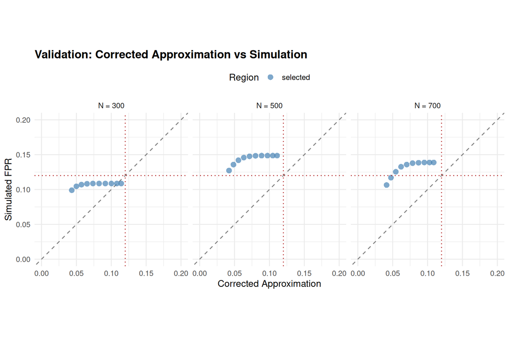

Corrected approximation vs simulated FPR.

```r
if (run_validation) {
  print(
    ggplot(val_fpr, aes(x = FPR_corr, y = Sim_FPR)) +
      geom_abline(slope = 1, intercept = 0, linetype = "dashed",
                  colour = "grey50") +
      geom_point(aes(colour = region, shape = region), size = 3,
                 alpha = 0.7) +
      geom_hline(yintercept = fpr_target, linetype = "dotted",
                 colour = "firebrick") +
      geom_vline(xintercept = fpr_target, linetype = "dotted",
                 colour = "firebrick") +
      scale_colour_manual(
        values = c("selected" = "steelblue",
                   "boundary" = "orange")) +
      facet_wrap(~ paste("N =", N)) +
      coord_equal(
        xlim = c(0, max(val_fpr$FPR_corr, 0.20)),
        ylim = c(0, max(val_fpr$Sim_FPR, 0.20))) +
      labs(x = "Corrected Approximation",
           y = "Simulated FPR",
           title = "Validation: Corrected Approximation vs Simulation",
           colour = "Region", shape = "Region") +
      theme_minimal(base_size = 12) +
      theme(legend.position = "top",
            plot.title = element_text(face = "bold"))
  )
} else {
  cat("Scatter plot skipped (nsims_val = 0).\n")
}
```

## 7.3 $L_{\text{eff}}$ Consistency Across Validated Pairs

```r
if (run_validation) {
  leff_diag <- val_fpr[!is.na(implied_L_eff), .(
    N, c1, c2,
    `Sim FPR` = sprintf("%.1f%%", 100 * Sim_FPR),
    `Calibrated` = round(L_eff_N, 2),
    `Implied` = round(implied_L_eff, 2),
    `Ratio` = L_eff_ratio
  )]

  if (nrow(leff_diag) > 0) {
    gt(leff_diag) |>
      tab_header(
        title = md("**L_eff Consistency: Calibrated vs Implied**"),
        subtitle = sprintf("Calibrated: L_eff = %.3f * (N/%d)^%.3f",
                            C_fit, n_min_val, alpha_fit)
      ) |>
      tab_style(style = cell_fill(color = "#E8F5E9"),
        locations = cells_body(columns = Ratio,
          rows = Ratio >= 0.7 & Ratio <= 1.3)) |>
      tab_style(style = cell_fill(color = "#FFEBEE"),
        locations = cells_body(columns = Ratio,
          rows = Ratio < 0.7 | Ratio > 1.3)) |>
      tab_source_note(paste(
        "Ratio = Implied / Calibrated.",
        "Green: within +/-30%.  Red: outside +/-30%.",
        "Stable ratio confirms L_eff is threshold-independent."))
  } else {
    cat("No valid implied L_eff values (all zero or NA).\n")
  }
} else {
  cat("L_eff diagnostic skipped (nsims_val = 0).\n")
}
```

Implied L_eff from simulation vs calibrated value.

**L_eff Consistency: Calibrated vs Implied**

Calibrated: L_eff = 0.338 * (N/60)^-0.062

| N | c1 | c2 | Sim FPR | Calibrated | Implied | Ratio |
| --- | --- | --- | --- | --- | --- | --- |
| 300 | 1.00 | 0.9 | 10.9% | 0.31 | 0.29 | 0.95 |
| 500 | 1.00 | 0.9 | 14.9% | 0.30 | 0.41 | 1.37 |
| 700 | 1.00 | 0.9 | 13.9% | 0.29 | 0.38 | 1.30 |
| 300 | 1.05 | 0.9 | 10.9% | 0.31 | 0.31 | 1.01 |
| 500 | 1.05 | 0.9 | 14.9% | 0.30 | 0.43 | 1.45 |
| 700 | 1.05 | 0.9 | 13.9% | 0.29 | 0.40 | 1.38 |
| 300 | 1.10 | 0.9 | 10.9% | 0.31 | 0.33 | 1.09 |
| 500 | 1.10 | 0.9 | 14.9% | 0.30 | 0.47 | 1.57 |
| 700 | 1.10 | 0.9 | 13.9% | 0.29 | 0.43 | 1.49 |
| 300 | 1.15 | 0.9 | 10.9% | 0.31 | 0.37 | 1.20 |
| 500 | 1.15 | 0.9 | 14.9% | 0.30 | 0.51 | 1.73 |
| 700 | 1.15 | 0.9 | 13.8% | 0.29 | 0.47 | 1.64 |
| 300 | 1.20 | 0.9 | 10.9% | 0.31 | 0.41 | 1.33 |
| 500 | 1.20 | 0.9 | 14.8% | 0.30 | 0.57 | 1.92 |
| 700 | 1.20 | 0.9 | 13.8% | 0.29 | 0.53 | 1.81 |
| 300 | 1.25 | 0.9 | 10.9% | 0.31 | 0.46 | 1.50 |
| 500 | 1.25 | 0.9 | 14.8% | 0.30 | 0.64 | 2.15 |
| 700 | 1.25 | 0.9 | 13.6% | 0.29 | 0.58 | 2.01 |
| 300 | 1.30 | 0.9 | 10.8% | 0.31 | 0.52 | 1.70 |
| 500 | 1.30 | 0.9 | 14.6% | 0.30 | 0.71 | 2.41 |
| 700 | 1.30 | 0.9 | 13.3% | 0.29 | 0.64 | 2.22 |
| 300 | 1.35 | 0.9 | 10.7% | 0.31 | 0.59 | 1.92 |
| 500 | 1.35 | 0.9 | 14.2% | 0.30 | 0.79 | 2.68 |
| 700 | 1.35 | 0.9 | 12.5% | 0.29 | 0.69 | 2.39 |
| 300 | 1.40 | 0.9 | 10.5% | 0.31 | 0.66 | 2.15 |
| 500 | 1.40 | 0.9 | 13.6% | 0.30 | 0.87 | 2.94 |
| 700 | 1.40 | 0.9 | 11.7% | 0.29 | 0.74 | 2.56 |
| 300 | 1.45 | 0.9 | 9.9% | 0.31 | 0.72 | 2.35 |
| 500 | 1.45 | 0.9 | 12.7% | 0.30 | 0.94 | 3.16 |
| 700 | 1.45 | 0.9 | 10.6% | 0.29 | 0.78 | 2.67 |

Ratio = Implied / Calibrated. Green: within +/-30%. Red: outside +/-30%. Stable ratio confirms L_eff is threshold-independent.

## 7.4 Confirmed Acceptable Pairs

```r
if (run_validation) {
  confirmed <- val_fpr[Sim_FPR <= fpr_target &
                        FPR_corr <= fpr_target]
  setorder(confirmed, N, -Sim_FPR)

  if (nrow(confirmed) > 0) {
    gt(confirmed[, .(N, c1, c2,
      `Corr FPR` = sprintf("%.1f%%", 100 * FPR_corr),
      `95% CI` = sprintf("[%.1f%%, %.1f%%]",
        100 * CI_lower, 100 * CI_upper),
      `Sim FPR` = sprintf("%.1f%%", 100 * Sim_FPR),
      `Sim/Corr` = round(Sim_FPR / pmax(FPR_corr, 0.001), 2),
      `In CI` = ifelse(in_CI, "Yes", "No")
    )]) |>
      tab_header(
        title = md(sprintf(
          "**Confirmed Pairs: FPR <= %.0f%% (Approx AND Sim)**",
          100 * fpr_target)),
        subtitle = sprintf("%d sims per config", nsims_val)
      ) |>
      tab_row_group(label = "N = 700", rows = N == 700) |>
      tab_row_group(label = "N = 500", rows = N == 500) |>
      tab_row_group(label = "N = 300", rows = N == 300) |>
      tab_style(style = cell_fill(color = "#E8F5E9"),
        locations = cells_body(columns = `In CI`,
          rows = `In CI` == "Yes")) |>
      tab_style(style = cell_fill(color = "#FFEBEE"),
        locations = cells_body(columns = `In CI`,
          rows = `In CI` == "No")) |>
      tab_source_note(paste(
        "95% CI bounds treat Corr FPR as the true rate.",
        "'In CI' = simulated FPR falls within expected range."))
  } else {
    cat("No pairs confirmed at this sim count.\n")
    cat("Consider increasing nsims_val.\n")
  }

} else {
  confirmed <- selected
  confirmed[, N := NA_integer_]
  cat("No simulation validation (nsims_val = 0).\n")
  cat(sprintf(
    "Approximation-selected pairs (corrected FPR <= %.0f%%): %d\n",
    100 * fpr_target, nrow(confirmed)))
  cat("Re-render with nsims_val > 0 to validate by simulation.\n")
}
```

Confirmed acceptable pairs

**Confirmed Pairs: FPR <= 12% (Approx AND Sim)**

5000 sims per config

| N | c1 | c2 | Corr FPR | 95% CI | Sim FPR | Sim/Corr | In CI |
| --- | --- | --- | --- | --- | --- | --- | --- |
| N = 300 |  |  |  |  |  |  |  |
| 300 | 1.00 | 0.9 | 11.4% | [10.6%, 12.3%] | 10.9% | 0.95 | Yes |
| 300 | 1.05 | 0.9 | 10.8% | [9.9%, 11.7%] | 10.9% | 1.01 | Yes |
| 300 | 1.10 | 0.9 | 10.0% | [9.2%, 10.8%] | 10.9% | 1.08 | No |
| 300 | 1.15 | 0.9 | 9.1% | [8.4%, 9.9%] | 10.9% | 1.19 | No |
| 300 | 1.20 | 0.9 | 8.3% | [7.5%, 9.0%] | 10.9% | 1.32 | No |
| 300 | 1.25 | 0.9 | 7.4% | [6.6%, 8.1%] | 10.9% | 1.47 | No |
| 300 | 1.30 | 0.9 | 6.5% | [5.8%, 7.2%] | 10.8% | 1.66 | No |
| 300 | 1.35 | 0.9 | 5.7% | [5.1%, 6.4%] | 10.7% | 1.87 | No |
| 300 | 1.40 | 0.9 | 5.0% | [4.4%, 5.6%] | 10.5% | 2.09 | No |
| 300 | 1.45 | 0.9 | 4.3% | [3.8%, 4.9%] | 9.9% | 2.28 | No |
| N = 700 |  |  |  |  |  |  |  |
| 700 | 1.40 | 0.9 | 4.7% | [4.2%, 5.3%] | 11.7% | 2.46 | No |
| 700 | 1.45 | 0.9 | 4.1% | [3.6%, 4.7%] | 10.6% | 2.58 | No |

95% CI bounds treat Corr FPR as the true rate. 'In CI' = simulated FPR falls within expected range.

# 8 Part V: Save Results

```r
# If recalibrated in this run, save the new L_eff values
if (recalibrate && exists("leff_cal")) {
  save_leff_calibration(
    C = C_fit, alpha = alpha_fit, n_min = n_min_val,
    outcome_type = "survival",
    cal_data = if (exists("cal_df")) cal_df else NULL,
    dgm_description = paste(
      "GBSG survival DGM,", length(confounders_base), "confounders",
      paste0("(", paste(confounders_base, collapse = ", "), "),"),
      sprintf("prop_cens=%.2f, p_harm=%.2f", prop_cens, p_harm)),
    n_sims_per_N = n_sims_recal,
    output_dir = output_dir,
    extra = list(
      confounders_base = confounders_base,
      prop_cens        = prop_cens,
      p_harm           = p_harm,
      hr_h1            = hr_h1,
      pcons            = pcons,
      fs_splits        = fs_splits,
      maxk_val         = maxk_val,
      n_min_val        = n_min_val,
      analysis_time    = analysis_time,
      cens_adjust      = cens_adjust,
      fpr_target       = fpr_target,
      N_cal_values     = N_cal_values,
      c1_range         = range(c1_grid),
      c2_range         = range(c2_grid)
    )
  )
}

results_bundle <- list(
  params = list(
    nsims_val = nsims_val, sim_seed = sim_seed,
    n_workers = n_workers,
    C_fit = C_fit, alpha_fit = alpha_fit,
    recalibrate = recalibrate,
    n_sims_recal = n_sims_recal,
    fpr_target = fpr_target,
    n_min_val = n_min_val, prop_cens = prop_cens,
    p_harm = p_harm, hr_h1 = hr_h1,
    pcons = pcons, analysis_time = analysis_time,
    cens_adjust = cens_adjust,
    N_target = N_target,
    c1_grid = c1_grid, c2_grid = c2_grid,
    timestamp = Sys.time()
  ),
  leff_source = list(
    C = C_fit, alpha = alpha_fit, n_min = n_min_val,
    source = if (recalibrate) "recalibrated in this run"
             else if (!is.null(cal_survival$timestamp))
               sprintf("loaded from .rds (calibrated %s)",
                 format(cal_survival$timestamp, "%Y-%m-%d"))
             else "fallback (hardcoded)"
  ),
  leff_raw_data = if (exists("cal_df")) cal_df else NULL,
  approx_grid = full_dt,
  sim_candidates = sim_candidates,
  frontier = frontier,
  val_results_raw = val_dt,
  val_fpr = val_fpr,
  confirmed = if (exists("confirmed")) confirmed else NULL,
  timings = timings
)

if (!is.null(output_dir)) {
  if (!dir.exists(output_dir)) dir.create(output_dir,
                                           recursive = TRUE)
  rds_path <- file.path(output_dir,
    sprintf("selection_survival_frontier_%s.rds",
            format(Sys.Date(), "%Y%m%d")))
  saveRDS(results_bundle, rds_path)
  cat(sprintf("Selection results saved to: %s\n", rds_path))
  cat(sprintf("  Size: %.1f KB\n", file.size(rds_path) / 1024))
} else {
  cat("Saving skipped (output_dir = NULL)\n")
}
```

```
#> Selection results saved to: _data/selection_survival_frontier_20260414.rds
#>   Size: 54.9 KB
```

## 8.1 How to Reload

```r
# --- Load L_eff calibration (for use in other documents) ---
cal <- load_leff_calibration("survival")
cal$C       # fitted C
cal$alpha   # fitted alpha

# --- Load the most recent selection results ---
res <- readRDS(latest_rds("selection_survival_frontier"))
res$leff_source    # Where L_eff came from
res$frontier       # Smallest c1 for each target
res$approx_grid    # Full approximation grid
res$val_fpr        # Simulation results (if run)
res$params$fpr_target   # FPR target used
```

# 9 Summary

```r
cat("=== Approximation-Driven Null Threshold Search ===\n\n")
```

```
#> === Approximation-Driven Null Threshold Search ===
```

```r
cat(sprintf("DGM: GBSG survival, %d confounders\n",
            length(confounders_base)))
```

```
#> DGM: GBSG survival, 7 confounders
```

```r
cat(sprintf("n.min=%d, pcons=%.2f, maxk=%d\n", n_min_val, pcons, maxk_val))
```

```
#> n.min=60, pcons=0.90, maxk=2
```

```r
cat(sprintf("prop_cens=%.2f, analysis_time=%d months\n",
            prop_cens, analysis_time))
```

```
#> prop_cens=0.46, analysis_time=84 months
```

```r
cat(sprintf("L_eff = %.3f * (N/%d)^%.3f",
            C_fit, n_min_val, alpha_fit))
```

```
#> L_eff = 0.338 * (N/60)^-0.062
```

```r
if (!recalibrate) cat("  [from prior calibration]")
```

```
#>   [from prior calibration]
```

```r
cat("\n\n")
```

```r
cat(sprintf("Dense grid: %d c1 x %d c2 values\n",
            length(c1_grid), length(c2_grid)))
```

```
#> Dense grid: 11 c1 x 8 c2 values
```

```r
cat(sprintf("Target: corrected FPR <= %.0f%% at all N in {%s}\n\n",
            100 * fpr_target,
            paste(N_target, collapse = ", ")))
```

```
#> Target: corrected FPR <= 12% at all N in {300, 500, 700}
```

```r
if (exists("frontier") && nrow(frontier) > 0) {
  c1_opt <- frontier$c1[1]
  c2_opt <- frontier$min_c2[1]

  cat("--- Optimal Pair: (c1_min, c2_min) ---\n")
  cat(sprintf("  c1_min = %.2f, c2_min = %.2f\n", c1_opt, c2_opt))
  cat(sprintf("  Corrected FPR: %.1f%% (target: %.0f%%)\n",
              100 * frontier$FPR_at_min_c2[1], 100 * fpr_target))
  cat(sprintf("  Per-subgroup P1(HR=1): %.1f%%\n",
              100 * p_detect_glm(1.0, d_dgm, c1_opt, c2_opt)))
  cat(sprintf("  Approx power at HR=%.1f: %.1f%%\n\n",
              hr_h1,
              100 * p_detect_glm(hr_h1, d_dgm, c1_opt, c2_opt)))

  cat("--- Full Frontier ---\n")
  for (r in seq_len(min(10, nrow(frontier)))) {
    cat(sprintf("  c1=%.2f: min c2=%.2f (corr FPR=%.1f%%)\n",
                frontier$c1[r], frontier$min_c2[r],
                100 * frontier$FPR_at_min_c2[r]))
  }
  if (nrow(frontier) > 10)
    cat(sprintf("  ... and %d more c1 values\n", nrow(frontier) - 10))
  cat("\n")
}
```

```
#> --- Optimal Pair: (c1_min, c2_min) ---
#>   c1_min = 1.00, c2_min = 0.90
#>   Corrected FPR: 10.9% (target: 12%)
#>   Per-subgroup P1(HR=1): 32.8%
#>   Approx power at HR=2.0: 89.1%
#>
#> --- Full Frontier ---
#>   c1=1.00: min c2=0.90 (corr FPR=10.9%)
#>   c1=1.05: min c2=0.90 (corr FPR=10.3%)
#>   c1=1.10: min c2=0.90 (corr FPR=9.5%)
#>   c1=1.15: min c2=0.90 (corr FPR=8.7%)
#>   c1=1.20: min c2=0.90 (corr FPR=7.8%)
#>   c1=1.25: min c2=0.90 (corr FPR=7.0%)
#>   c1=1.30: min c2=0.90 (corr FPR=6.2%)
#>   c1=1.35: min c2=0.90 (corr FPR=5.4%)
#>   c1=1.40: min c2=0.90 (corr FPR=4.7%)
#>   c1=1.45: min c2=0.90 (corr FPR=4.1%)
#>   ... and 1 more c1 values
```

```r
cat(sprintf("Selected: %d pairs | Boundary: %d pairs\n",
            sum(sim_candidates$region == "selected"),
            sum(sim_candidates$region == "boundary")))
```

```
#> Selected: 72 pairs | Boundary: 0 pairs
```

```r
if (run_validation) {
  n_confirmed <- if (!is.null(confirmed)) nrow(confirmed) else 0
  cat(sprintf("Confirmed: %d configs\n", n_confirmed))
} else {
  cat("Validation: SKIPPED (nsims_val = 0)\n")
  cat("Set nsims_val > 0 (e.g., 30 for quick check, 500 for\n")
  cat("production) and re-render to validate by simulation.\n")
}
```

```
#> Confirmed: 12 configs
```

```r
cat("\n--- Paper defaults (c1=1.25, c2=1.0) ---\n")
```

```
#>
#> --- Paper defaults (c1=1.25, c2=1.0) ---
```

```r
paper <- fpr_wide[c1 == 1.25 & c2 == 1.00]
if (nrow(paper) > 0) {
  cat(sprintf("  Corrected FPR at N=%d: %.1f%%\n",
              N_max, 100 * paper$FPR_corr_worst))
  cat("  (For survival, paper defaults are typically adequate.)\n")
}
```

```
#>   Corrected FPR at N=700: 6.1%
#>   (For survival, paper defaults are typically adequate.)
```

# 10 Timing and Session Info

```r
timings$total <- (proc.time() - t_vignette_start)["elapsed"]

stages <- c("DGM", "L_eff Calibration")
seconds <- c(timings$dgm, timings$leff_cal)
if (run_validation) {
  stages <- c(stages, "Validation Simulation")
  seconds <- c(seconds, timings$validation)
}
if (timings$power > 0) {
  stages <- c(stages, "Power Simulation (H1)")
  seconds <- c(seconds, timings$power)
}
stages <- c(stages, "Total")
seconds <- c(seconds, timings$total)

timing_df <- data.frame(
  Stage = stages, Seconds = seconds,
  stringsAsFactors = FALSE
)
timing_df$Minutes <- timing_df$Seconds / 60
timing_df$Hours   <- timing_df$Seconds / 3600

# ── Per-1,000 simulation projection ──────────────────────────
sim_secs <- timings$leff_cal +
  (if (run_validation) timings$validation else 0) +
  timings$power
n_total_sims <- (if (recalibrate) n_sims_recal * length(N_cal_values) else 0L) +
  (if (run_validation) nrow(sim_candidates) * length(N_target) * nsims_val else 0L) +
  (if (nsims_power > 0) nsims_power * length(N_target) else 0L)

if (n_total_sims > 0) {
  secs_per_sim <- sim_secs / n_total_sims
  proj_1k <- secs_per_sim * 1000
  timing_df <- rbind(timing_df, data.frame(
    Stage   = sprintf("Projected per 1,000 sims (%d actual)", n_total_sims),
    Seconds = proj_1k,
    Minutes = proj_1k / 60,
    Hours   = proj_1k / 3600,
    stringsAsFactors = FALSE
  ))
}

subtitle_text <- if (run_validation) {
  sprintf("%d pairs x %d N x %d sims | %d workers",
    nrow(sim_candidates), length(N_target),
    nsims_val, n_workers)
} else {
  sprintf("Approximation only | %d workers", n_workers)
}

gt(timing_df) |>
  tab_header(
    title = "Computational Timing Summary",
    subtitle = subtitle_text
  ) |>
  fmt_number(columns = Seconds, decimals = 1) |>
  fmt_number(columns = Minutes, decimals = 2) |>
  fmt_number(columns = Hours,   decimals = 3) |>
  cols_label(Stage = "Stage", Seconds = "Time (sec)",
             Minutes = "Time (min)", Hours = "Time (hr)") |>
  tab_style(
    style = cell_text(weight = "bold"),
    locations = cells_body(rows = grepl("Total|Projected", Stage))
  )
```

Computational Timing Summary

| Stage | Time (sec) | Time (min) | Time (hr) |
| --- | --- | --- | --- |
| DGM | 0.1 | 0.00 | 0.000 |
| L_eff Calibration | 0.0 | 0.00 | 0.000 |
| Validation Simulation | 9,927.1 | 165.45 | 2.758 |
| Power Simulation (H1) | 148.8 | 2.48 | 0.041 |
| Total | 10,106.6 | 168.44 | 2.807 |
| Projected per 1,000 sims (1081500 actual) | 9.3 | 0.16 | 0.003 |

```r
plan(sequential)
```